# White and Red Wine Quality by Jennifer Joo

For this project, we will look at a dataset of red and white verde wine samples. The variables in the dataset include:

fixed acidity volatile acidity citric acid residual sugar chlorides free sulfur dioxide total sulfur dioxide density pH sulphates alcohol quality (score between 0 and 10) type (red, white)

# Univariate Plots Section

We will begin the analysis by looking at the distribution of each of the above variables individually to see if they’re skewed, contain outliers, etc. We’ll also take a quick look at the overall structure of the data and some summary statistics (mean, median, quartiles)

```
## 'data.frame':    6497 obs. of  13 variables:
##  $ fixed.acidity       : num  7.4 7.8 7.8 11.2 7.4 7.4 7.9 7.3 7.8 7.5 ...
##  $ volatile.acidity    : num  0.7 0.88 0.76 0.28 0.7 0.66 0.6 0.65 0.58 0.5 ...
##  $ citric.acid         : num  0 0 0.04 0.56 0 0 0.06 0 0.02 0.36 ...
##  $ residual.sugar      : num  1.9 2.6 2.3 1.9 1.9 1.8 1.6 1.2 2 6.1 ...
##  $ chlorides           : num  0.076 0.098 0.092 0.075 0.076 0.075 0.069 0.065 0.073 0.071 ...
##  $ free.sulfur.dioxide : num  11 25 15 17 11 13 15 15 9 17 ...
##  $ total.sulfur.dioxide: num  34 67 54 60 34 40 59 21 18 102 ...
##  $ density             : num  0.998 0.997 0.997 0.998 0.998 ...
##  $ pH                  : num  3.51 3.2 3.26 3.16 3.51 3.51 3.3 3.39 3.36 3.35 ...
##  $ sulphates           : num  0.56 0.68 0.65 0.58 0.56 0.56 0.46 0.47 0.57 0.8 ...
##  $ alcohol             : num  9.4 9.8 9.8 9.8 9.4 9.4 9.4 10 9.5 10.5 ...
##  $ quality             : int  5 5 5 6 5 5 5 7 7 5 ...
##  $ type                : chr  "red" "red" "red" "red" ...
```

```
##  fixed.acidity    volatile.acidity  citric.acid     residual.sugar
##  Min.   : 3.800   Min.   :0.0800   Min.   :0.0000   Min.   : 0.600
##  1st Qu.: 6.400   1st Qu.:0.2300   1st Qu.:0.2500   1st Qu.: 1.800
##  Median : 7.000   Median :0.2900   Median :0.3100   Median : 3.000
##  Mean   : 7.215   Mean   :0.3397   Mean   :0.3186   Mean   : 5.443
##  3rd Qu.: 7.700   3rd Qu.:0.4000   3rd Qu.:0.3900   3rd Qu.: 8.100
##  Max.   :15.900   Max.   :1.5800   Max.   :1.6600   Max.   :65.800
##    chlorides       free.sulfur.dioxide total.sulfur.dioxide
##  Min.   :0.00900   Min.   :  1.00      Min.   :  6.0
##  1st Qu.:0.03800   1st Qu.: 17.00      1st Qu.: 77.0
##  Median :0.04700   Median : 29.00      Median :118.0
##  Mean   :0.05603   Mean   : 30.53      Mean   :115.7
##  3rd Qu.:0.06500   3rd Qu.: 41.00      3rd Qu.:156.0
##  Max.   :0.61100   Max.   :289.00      Max.   :440.0
##     density             pH          sulphates         alcohol
##  Min.   :0.9871   Min.   :2.720   Min.   :0.2200   Min.   : 8.00
##  1st Qu.:0.9923   1st Qu.:3.110   1st Qu.:0.4300   1st Qu.: 9.50
##  Median :0.9949   Median :3.210   Median :0.5100   Median :10.30
##  Mean   :0.9947   Mean   :3.219   Mean   :0.5313   Mean   :10.49
##  3rd Qu.:0.9970   3rd Qu.:3.320   3rd Qu.:0.6000   3rd Qu.:11.30
##  Max.   :1.0390   Max.   :4.010   Max.   :2.0000   Max.   :14.90
##     quality          type
##  Min.   :3.000   Length:6497
##  1st Qu.:5.000   Class :character
##  Median :6.000   Mode  :character
##  Mean   :5.818
##  3rd Qu.:6.000
##  Max.   :9.000
```

We have a categorical variable and 12 numeric/integer variables. The single categorical variable is ‘type’, which indicates whether a datapoint is associated is a red or white wine.

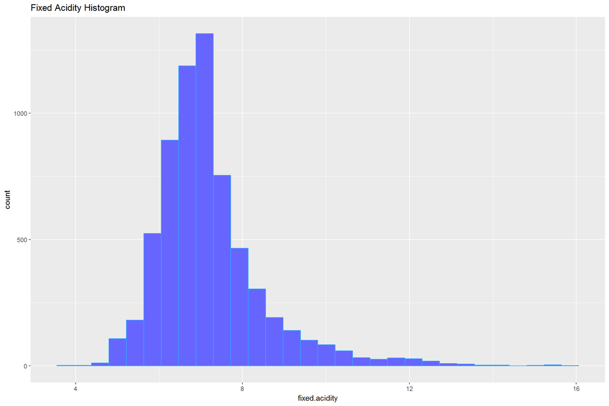

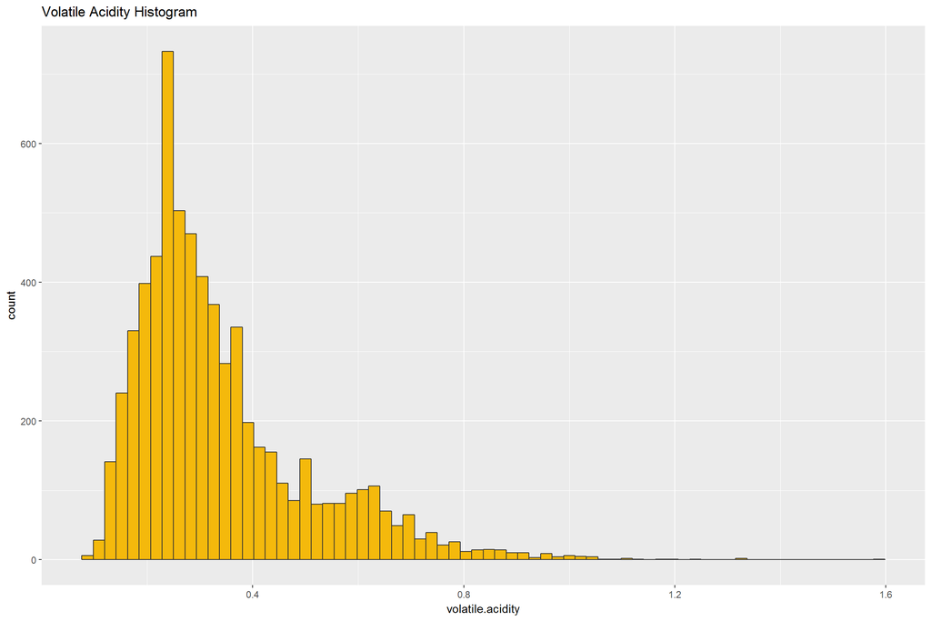

[figure not shown]

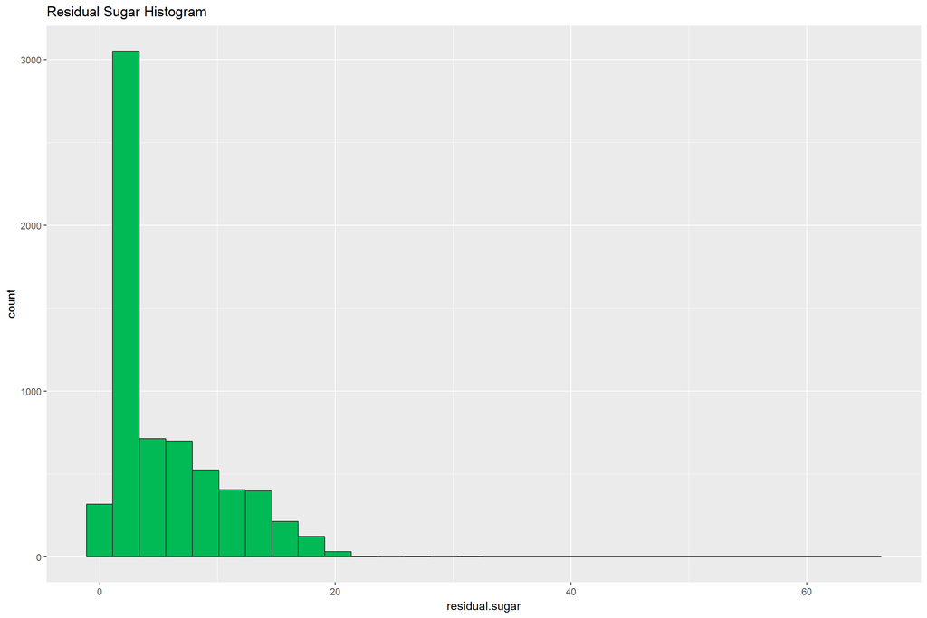

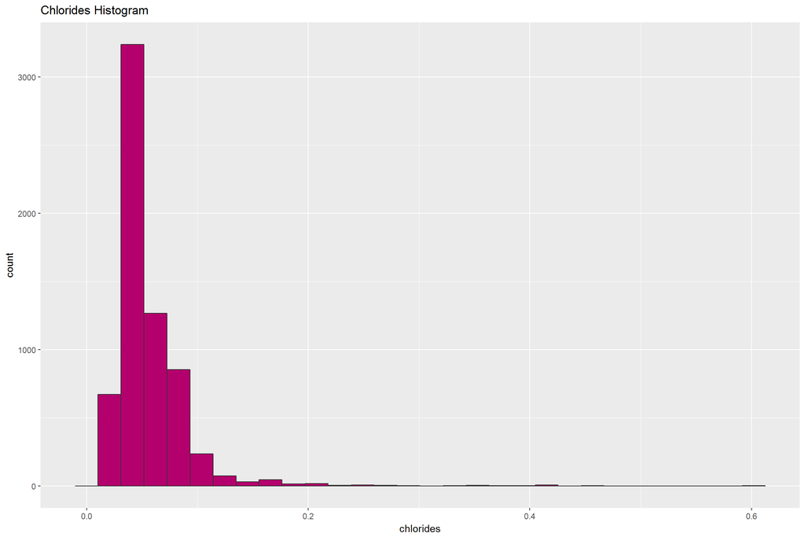

The chlorides histogram is approximately normal with a long right tail.

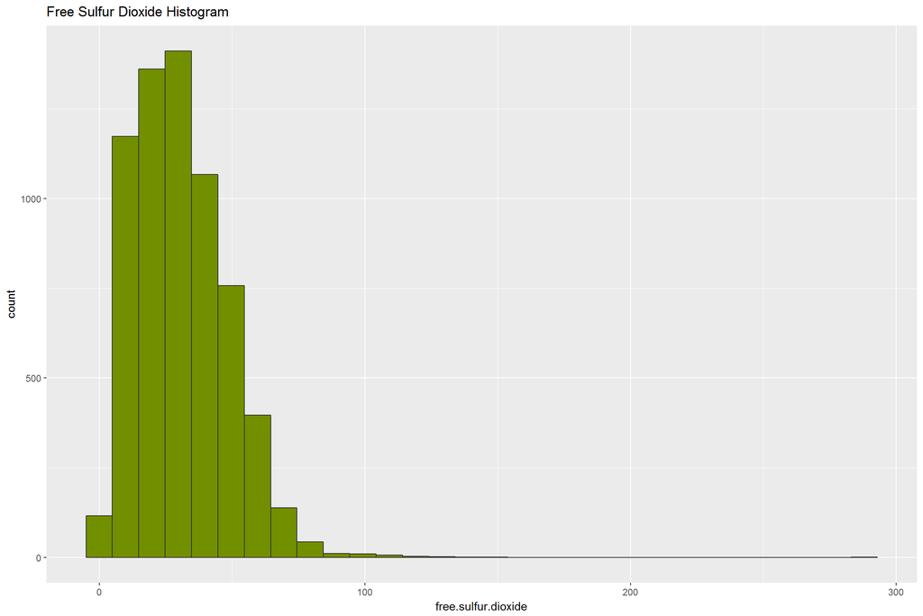

The free sulfur dioxide histogram is approximately normal with an outlier at ~290.

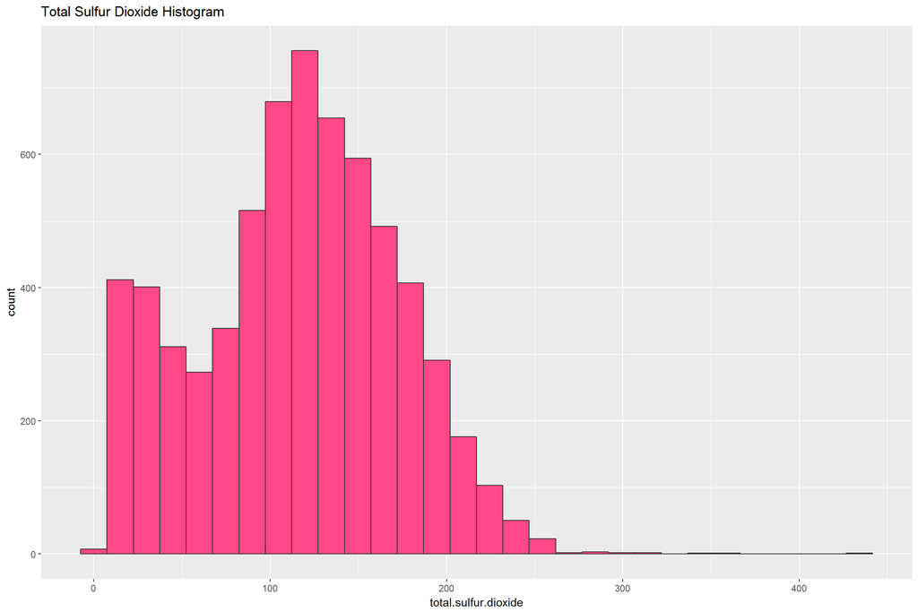

The total sulfur dioxide histogram has two peaks at around 20 and 120 with a few outliers above 300.

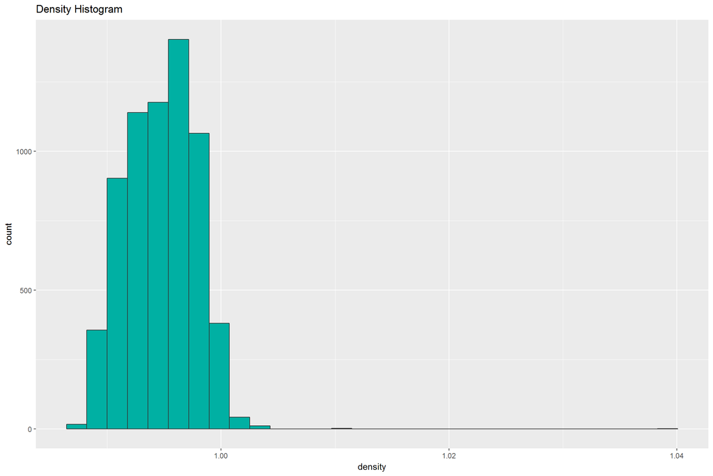

The density histogram is somewhat normal with outliers at around 1.01 and 1.04

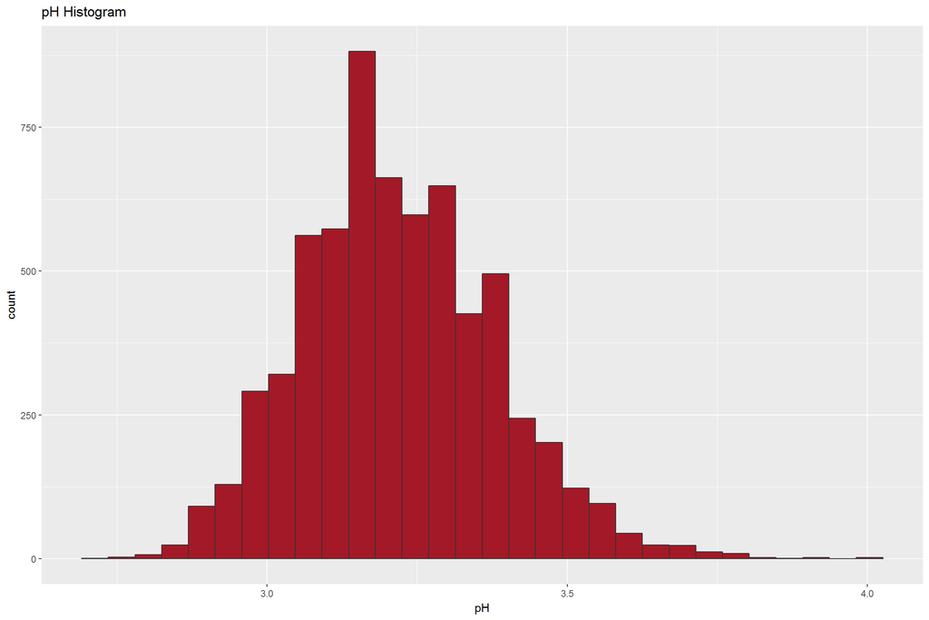

The pH histogram is approximately normal; it’s interesting to note that all wines have a pH of about 4 or lower so all wines are at least somewhat acidic.

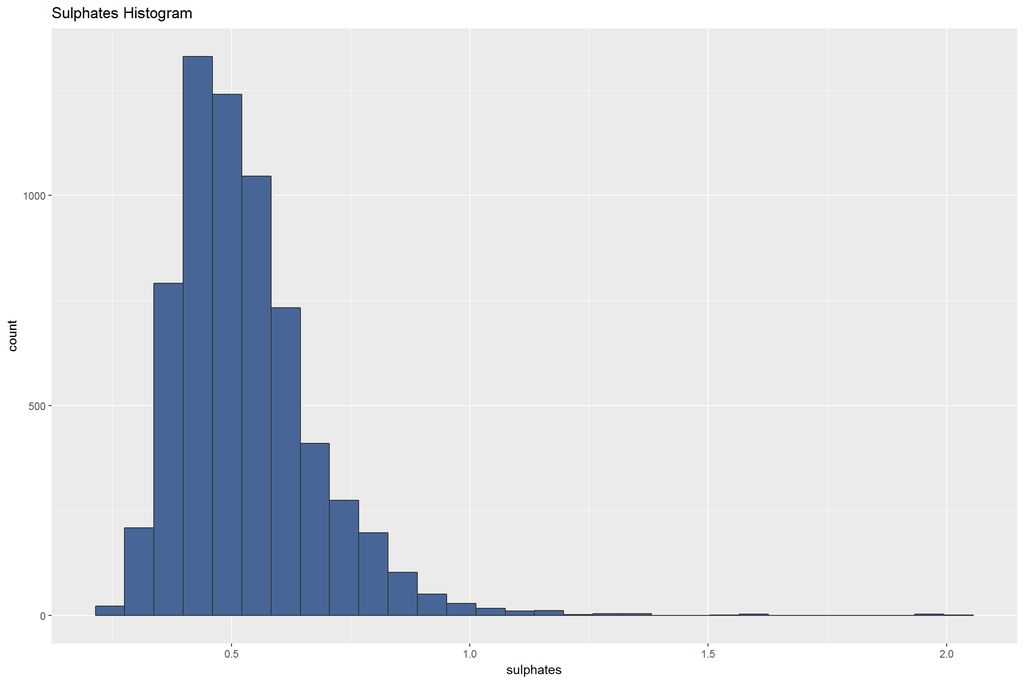

The sulphates histogram is approximately normal with a right skew. Most values are less than 1.0

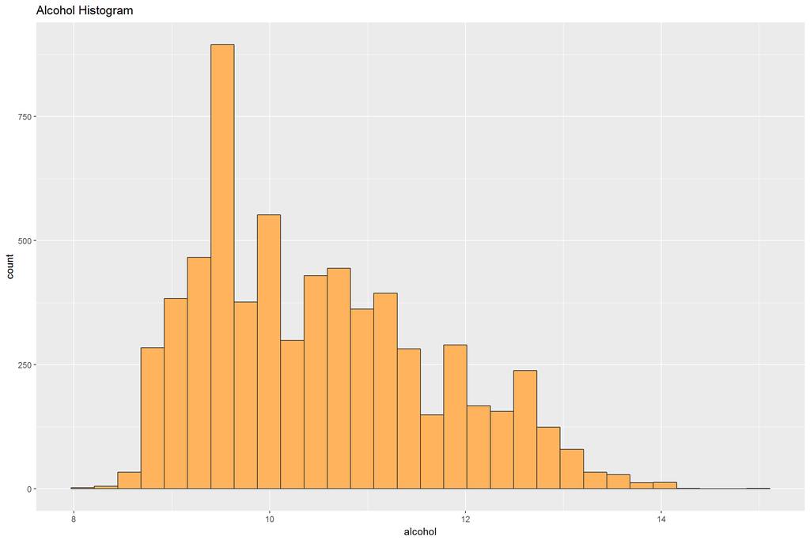

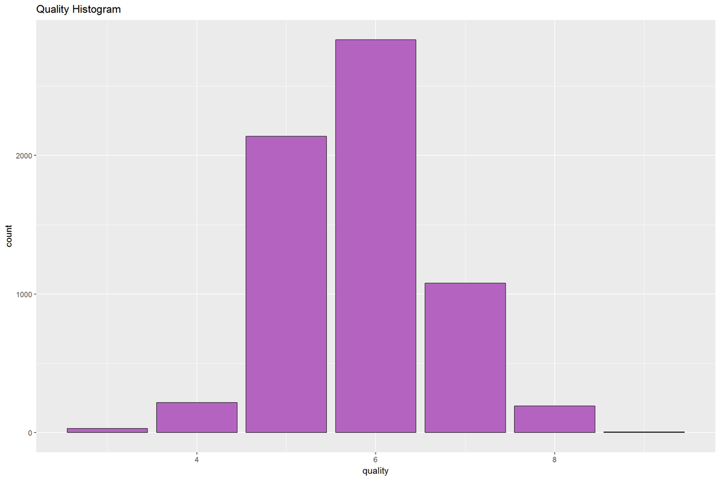

The quality histogram is approximately normal; most wines have a rating of 6 and the second most common rating is a 5. The unevent distribution here may affect our analysis later on since there are few wines rated a 3 or 9.

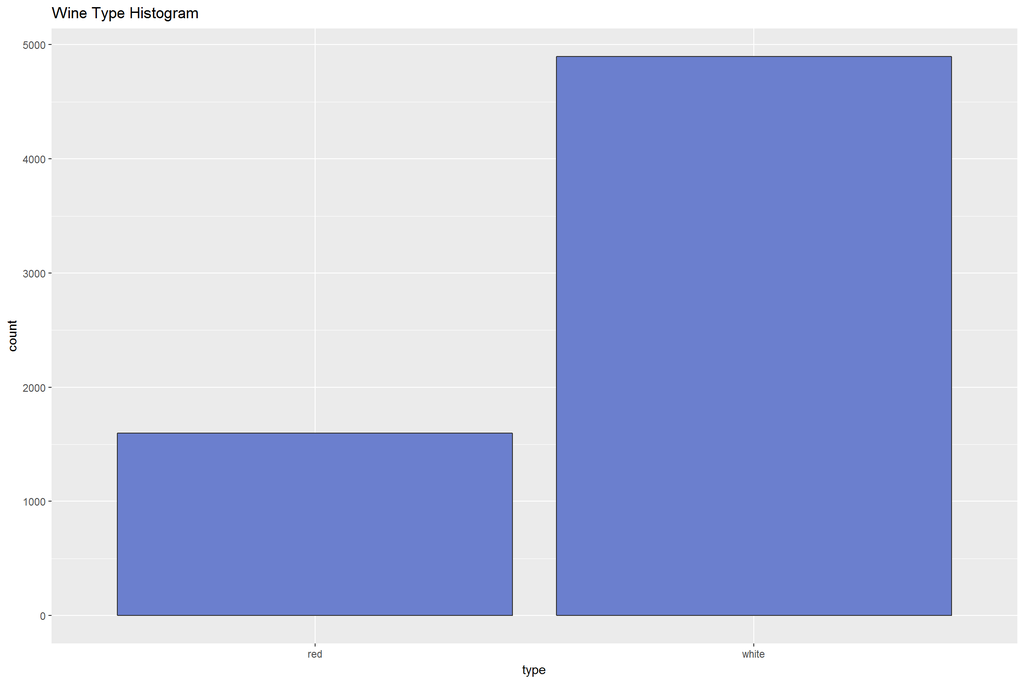

There are about 3 times as many white wines as red wines, which is important to note since it will affect how later multivariate graphs may be perceived.

# Univariate Analysis

### What is the structure of your dataset?

There are 6,497 observations and 13 variables. All but one variable (‘type’) have a data type of numeric or integer. Most of the numeric/integer variables have an approximately normal distribution and most variables have some outliers.

### What is/are the main feature(s) of interest in your dataset?

The main features of interest are quality, which is a score between 0 and 10, and type, a created variable that indicates whether the wine is red or white. However, it is important to note that available quality scores range from 3 to 9. The quality instagram is approximately normal although ideally, we would like an equal distribution of scores across both red and white wines.

### What other features in the dataset do you think will help support your investigation into your feature(s) of interest?

Without looking further at the data set, I think that pH and alcohol may be important.

### Did you create any new variables from existing variables in the dataset?

Yes, I merge the red wine and white wine datasets and created the variable “type” to indicate which dataset the observations came from. The possible values are “red” and “white”. It’s important to note that this dataset is unbalanced; there are about 3 times as many white wines as red wines in this dataset.

### Of the features you investigated, were there any unusual distributions? Did you perform any operations on the data to tidy, adjust, or change the form of the data? If so, why did you do this?

# Bivariate Plots Section

We’ll first create a box plot by quality and wine type to see if quality ratings for red and white wines vary drastically.

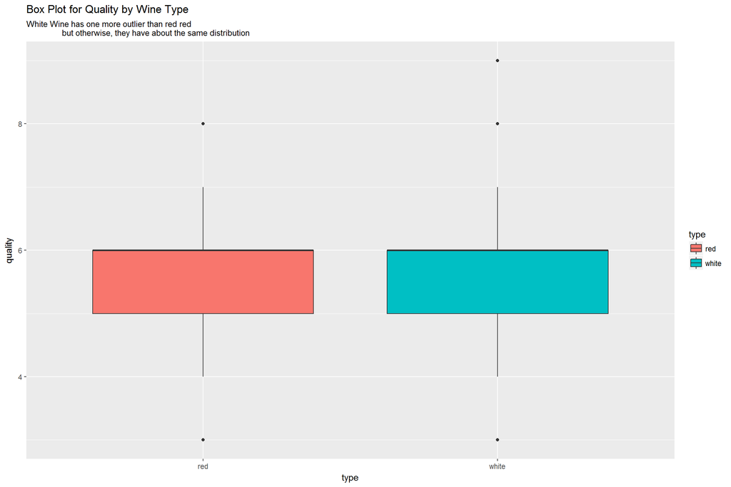

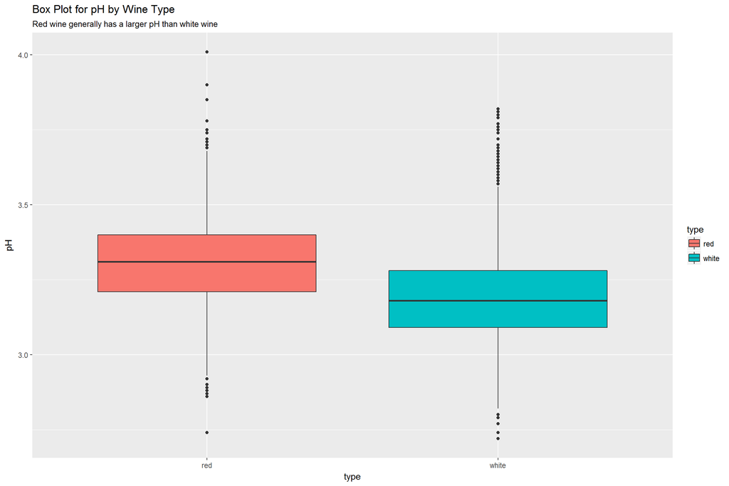

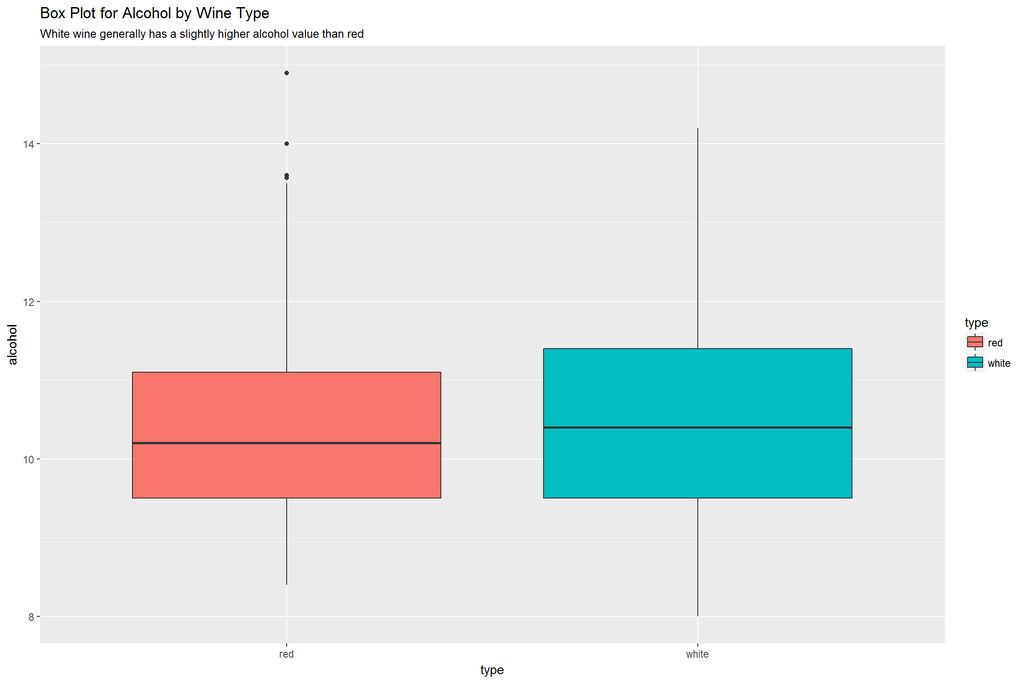

```
## [1] "pH Quartiles for red and white wine: "
```

```
##   0%  25%  50%  75% 100%
## 2.74 3.21 3.31 3.40 4.01
```

```
##   0%  25%  50%  75% 100%
## 2.72 3.09 3.18 3.28 3.82
```

```
## [1] "Alcohol Quartiles for red and white wine: "
```

```
##   0%  25%  50%  75% 100%
##  8.4  9.5 10.2 11.1 14.9
```

```
##   0%  25%  50%  75% 100%
##  8.0  9.5 10.4 11.4 14.2
```

```
##                      fixed.acidity volatile.acidity citric.acid
## fixed.acidity                 1.00             0.22        0.32
## volatile.acidity              0.22             1.00       -0.38
## citric.acid                   0.32            -0.38        1.00
## residual.sugar               -0.11            -0.20        0.14
## chlorides                     0.30             0.38        0.04
## free.sulfur.dioxide          -0.28            -0.35        0.13
## total.sulfur.dioxide         -0.33            -0.41        0.20
## density                       0.46             0.27        0.10
## pH                           -0.25             0.26       -0.33
## sulphates                     0.30             0.23        0.06
## alcohol                      -0.10            -0.04       -0.01
## quality                      -0.08            -0.27        0.09
##                      residual.sugar chlorides free.sulfur.dioxide
## fixed.acidity                 -0.11      0.30               -0.28
## volatile.acidity              -0.20      0.38               -0.35
## citric.acid                    0.14      0.04                0.13
## residual.sugar                 1.00     -0.13                0.40
## chlorides                     -0.13      1.00               -0.20
## free.sulfur.dioxide            0.40     -0.20                1.00
## total.sulfur.dioxide           0.50     -0.28                0.72
## density                        0.55      0.36                0.03
## pH                            -0.27      0.04               -0.15
## sulphates                     -0.19      0.40               -0.19
## alcohol                       -0.36     -0.26               -0.18
## quality                       -0.04     -0.20                0.06
##                      total.sulfur.dioxide density    pH sulphates alcohol
## fixed.acidity                       -0.33    0.46 -0.25      0.30   -0.10
## volatile.acidity                    -0.41    0.27  0.26      0.23   -0.04
## citric.acid                          0.20    0.10 -0.33      0.06   -0.01
## residual.sugar                       0.50    0.55 -0.27     -0.19   -0.36
## chlorides                           -0.28    0.36  0.04      0.40   -0.26
## free.sulfur.dioxide                  0.72    0.03 -0.15     -0.19   -0.18
## total.sulfur.dioxide                 1.00    0.03 -0.24     -0.28   -0.27
## density                              0.03    1.00  0.01      0.26   -0.69
## pH                                  -0.24    0.01  1.00      0.19    0.12
## sulphates                           -0.28    0.26  0.19      1.00    0.00
## alcohol                             -0.27   -0.69  0.12      0.00    1.00
## quality                             -0.04   -0.31  0.02      0.04    0.44
##                      quality
## fixed.acidity          -0.08
## volatile.acidity       -0.27
## citric.acid             0.09
## residual.sugar         -0.04
## chlorides              -0.20
## free.sulfur.dioxide     0.06
## total.sulfur.dioxide   -0.04
## density                -0.31
## pH                      0.02
## sulphates               0.04
## alcohol                 0.44
## quality                 1.00
```

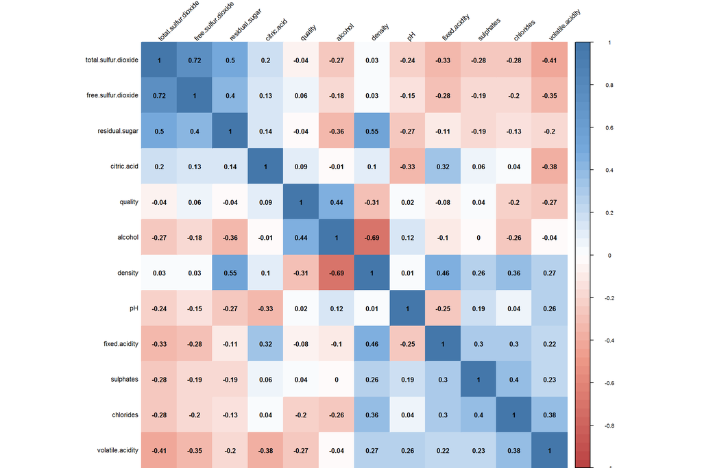

# Bivariate Analysis

### Talk about some of the relationships you observed in this part of the investigation. How did the feature(s) of interest vary with other features in the dataset?

In the box plots, quality didn’t vary much by wine type; the majority of the datapoints had a quality rating of 5 or 6, although there white wines had an outlier that had a quality of 9. This may be due to the fact that very few wines were rated a 3 or 9.

However, it is interesting to note that red wines were generally less acidic (had a higher pH value) than white wines. White wines also had more outliers in this box plot distribution although there are also more observations for white wines, so this I wouldn’t consider this too unusual. White wines had a median pH of 3.18 and red wines had a median pH of 3.31, with a difference of 0.13.

### Did you observe any interesting relationships between the other features (not the main feature(s) of interest)?

### What was the strongest relationship you found?

The strongest relationship was between total.sulfur.dioxide and free.sulfur.dioxide which has a correlation of 0.72, which made sense since they were both measures of sulfur dioxide. The next strongest was between density and residual.sugar with a correlation of 0.55.

The two variables that had the largest negative correlation was alcohol and density. The most interesting relationship was between quality and alcohol, which had a correlation coefficient of 0.44.

# Multivariate Plots Section

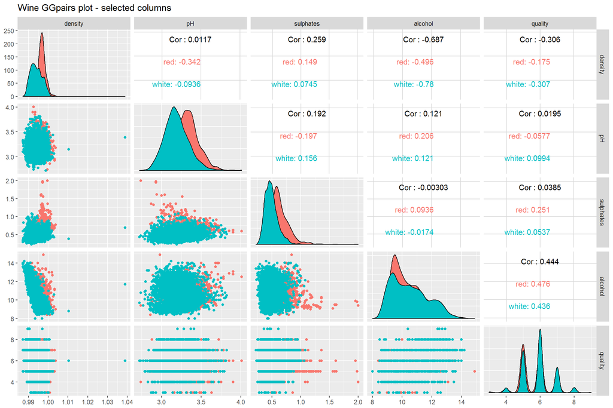

For pH, sulphates, alcohol, and quality, red and white wines have similar distribution shapes although for pH and sulphates, red wines have a somewhat larger pH and sulphares median, which we saw in the bivariate plots section.

Red and white wines have different distributions when we look at density. Red wines have a density distribution that is tall and narrow while white wines have a density distribution that is shorter and wider. We also see two consistent outliers for white wines when we compare density to pH, sulphates, alcohol, and quality.

[figure not shown]

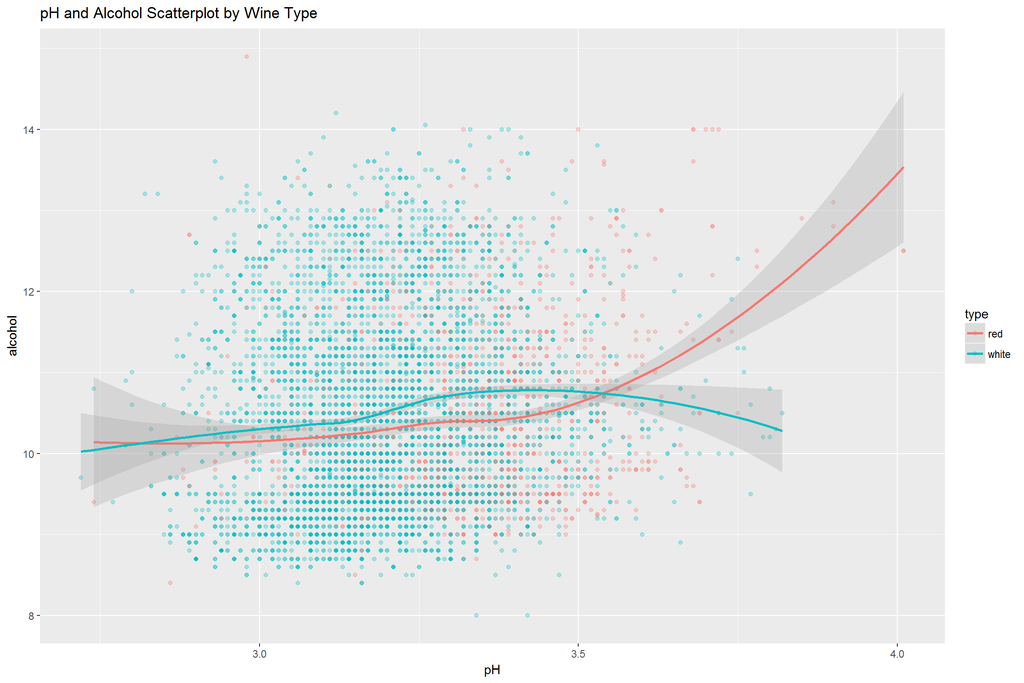

There isn’t a clear negative or positive correlation between alcohol and pH either for white wine. The line for red wine slants upward after a pH of 3.5 but this may be due to outliers.

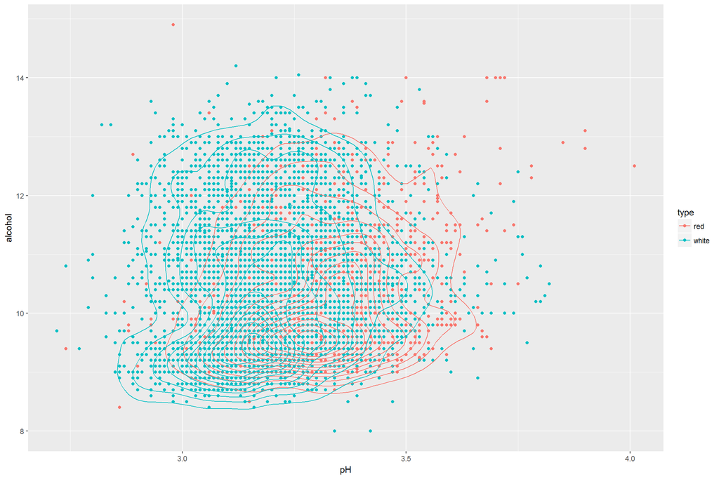

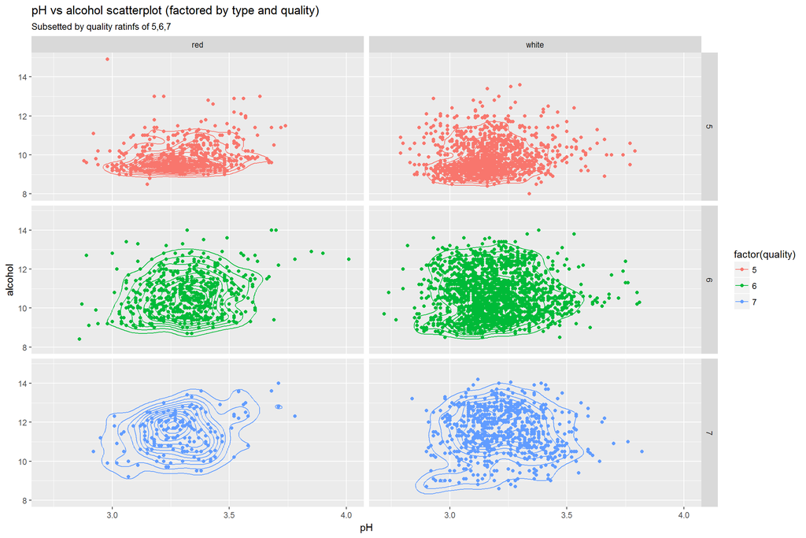

There appears to be weak correlation between pH and alcohol for both red and white wines at quality ratings of 5, 6, and 7.

# Multivariate Analysis

### Talk about some of the relationships you observed in this part of the investigation. Were there features that strengthened each other in terms of looking at your feature(s) of interest?

### Were there any interesting or surprising interactions between features?

The relationship between alcohol and pH was positive for red wines at a pH level greater than 3.5. Overall, the relationship between pH and quality did not have a very positive relationship for white wines. However, for red wines, there was a slight negative relationship between quality and pH for red wines.

### OPTIONAL: Did you create any models with your dataset? Discuss the strengths and limitations of your model.

# Final Plots and Summary

### Plot One

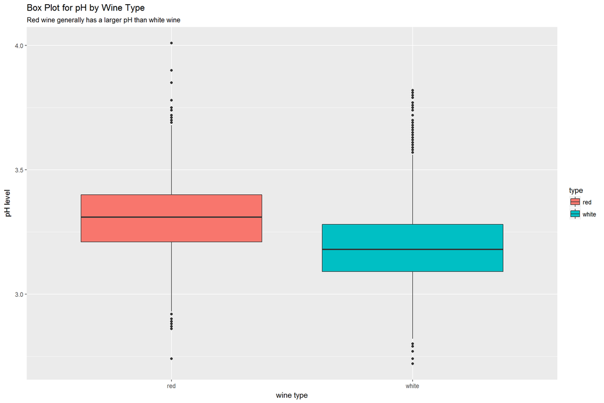

### Box Plot for pH by Wine Type

Red wines were somewhat less acidic (had a higher pH value) than white wines. White wines also had more outliers in this box plot distribution although there are also more observations for white wines, so this is expected. White wines had a median pH of 3.18 and red wines had a median pH of 3.31, with a difference of 0.13.

### Plot Two

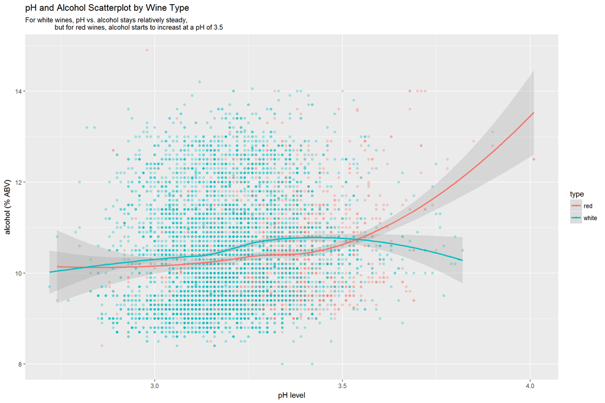

### pH and Alcohol Scatterplot by Wine Type

There isn’t a clear negative or positive correlation between alcohol and pH either for white wine. The line for red wine slants upward after a pH of 3.5 but this may be due to outliers.

### Plot Three

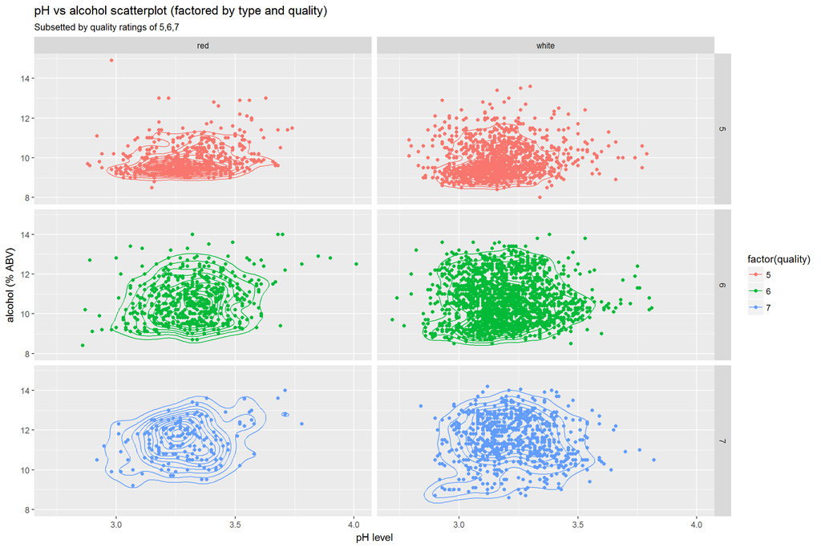

### pH and Alcohol scatterplot (factored by type and quality of 5, 6, and 7)

# Reflection

For future work, I would also like to attempt to predict a wine’s quality rating based on the other provided variables. Not one variable had a very strong correlation with quality. Alcohol had the highest correlation value with quality at 0.44.